# CS 422 Section 01 hw2

Rui Zou A20351034

## 2.1 Decision Tree Classification

### (a)

```r
setwd("/Users/rzou/Academics/Courses/CS422 - Data Mining/homeworks/hw2")
set.seed(1122)
train_raw = read.csv("adult-train.csv", header=T, sep=",")
train_raw
```

| age | workclass | fnlwgt | education | education_num | marital_status | occupation | relationship | race | sex | capital_gain | capital_loss | hours_per_week | native_country | income |
| --- | --- | --- | --- | --- | --- | --- | --- | --- | --- | --- | --- | --- | --- | --- |
| 39 | State-gov | 77516 | Bachelors | 13 | Never-married | Adm-clerical | Not-in-family | White | Male | 2174 | 0 | 40 | United-States | <=50K |
| 50 | Self-emp-not-inc | 83311 | Bachelors | 13 | Married-civ-spouse | Exec-managerial | Husband | White | Male | 0 | 0 | 13 | United-States | <=50K |
| 38 | Private | 215646 | HS-grad | 9 | Divorced | Handlers-cleaners | Not-in-family | White | Male | 0 | 0 | 40 | United-States | <=50K |
| 53 | Private | 234721 | 11th | 7 | Married-civ-spouse | Handlers-cleaners | Husband | Black | Male | 0 | 0 | 40 | United-States | <=50K |
| 28 | Private | 338409 | Bachelors | 13 | Married-civ-spouse | Prof-specialty | Wife | Black | Female | 0 | 0 | 40 | Cuba | <=50K |
| 37 | Private | 284582 | Masters | 14 | Married-civ-spouse | Exec-managerial | Wife | White | Female | 0 | 0 | 40 | United-States | <=50K |
| 49 | Private | 160187 | 9th | 5 | Married-spouse-absent | Other-service | Not-in-family | Black | Female | 0 | 0 | 16 | Jamaica | <=50K |
| 52 | Self-emp-not-inc | 209642 | HS-grad | 9 | Married-civ-spouse | Exec-managerial | Husband | White | Male | 0 | 0 | 45 | United-States | >50K |
| 31 | Private | 45781 | Masters | 14 | Never-married | Prof-specialty | Not-in-family | White | Female | 14084 | 0 | 50 | United-States | >50K |
| 42 | Private | 159449 | Bachelors | 13 | Married-civ-spouse | Exec-managerial | Husband | White | Male | 5178 | 0 | 40 | United-States | >50K |

[output cut: 990 more lines]

```r
sum(train_raw$occupation=="?")
```

```
[1] 1843
```

```r
which(train_raw$occupation=="?")
```

```
   [1]    28    62    70    78   107   129   150   155   161   188   202   222
  [13]   227   244   267   298   313   327   347   348   355   398   409   431
  [25]   432   450   460   472   485   487   500   512   516   518   519   540
  [37]   577   581   591   592   597   649   657   669   672   687   696   735
  [49]   789   790   793   807   812   831   835   886   891   904   925   932
  [61]   970   983  1020  1035  1036  1040  1047  1098  1101  1132  1135  1153
  [73]  1168  1176  1181  1186  1209  1216  1218  1263  1283  1291  1313  1318
  [85]  1326  1348  1350  1372  1389  1405  1421  1434  1442  1453  1459  1505
  [97]  1545  1563  1570  1571  1575  1580  1593  1607  1630  1657  1666  1677
 [109]  1705  1708  1759  1762  1774  1779  1824  1847  1852  1866  1879  1924
 [121]  1932  1972  1988  2026  2037  2047  2062  2073  2085  2092  2095  2106
 [133]  2119  2127  2153  2156  2164  2165  2211  2214  2223  2282  2293  2324
 [145]  2328  2341  2355  2357  2359  2360  2373  2381  2383  2398  2421  2428
 [157]  2465  2477  2487  2492  2497  2507  2514  2522  2545  2567  2571  2572
 [169]  2579  2587  2595  2607  2633  2635  2639  2674  2677  2690  2752  2761
```

[output cut: 70 more lines]

```r
dirty_rows_train = integer()
for (i in 1:ncol(train_raw)){
    dirty_rows_train <- c(dirty_rows_train, which(train_raw[[i]] == "?"))
}
length(unique(dirty_rows_train))
```

```
[1] 2399
```

```r
train = train_raw[-c(dirty_rows_train),]
train
```

|  | age | workclass | fnlwgt | education | education_num | marital_status | occupation | relationship | race | sex | capital_gain | capital_loss | hours_per_week | native_country | income |
| --- | --- | --- | --- | --- | --- | --- | --- | --- | --- | --- | --- | --- | --- | --- | --- |
| 1 | 39 | State-gov | 77516 | Bachelors | 13 | Never-married | Adm-clerical | Not-in-family | White | Male | 2174 | 0 | 40 | United-States | <=50K |
| 2 | 50 | Self-emp-not-inc | 83311 | Bachelors | 13 | Married-civ-spouse | Exec-managerial | Husband | White | Male | 0 | 0 | 13 | United-States | <=50K |
| 3 | 38 | Private | 215646 | HS-grad | 9 | Divorced | Handlers-cleaners | Not-in-family | White | Male | 0 | 0 | 40 | United-States | <=50K |
| 4 | 53 | Private | 234721 | 11th | 7 | Married-civ-spouse | Handlers-cleaners | Husband | Black | Male | 0 | 0 | 40 | United-States | <=50K |
| 5 | 28 | Private | 338409 | Bachelors | 13 | Married-civ-spouse | Prof-specialty | Wife | Black | Female | 0 | 0 | 40 | Cuba | <=50K |
| 6 | 37 | Private | 284582 | Masters | 14 | Married-civ-spouse | Exec-managerial | Wife | White | Female | 0 | 0 | 40 | United-States | <=50K |
| 7 | 49 | Private | 160187 | 9th | 5 | Married-spouse-absent | Other-service | Not-in-family | Black | Female | 0 | 0 | 16 | Jamaica | <=50K |
| 8 | 52 | Self-emp-not-inc | 209642 | HS-grad | 9 | Married-civ-spouse | Exec-managerial | Husband | White | Male | 0 | 0 | 45 | United-States | >50K |
| 9 | 31 | Private | 45781 | Masters | 14 | Never-married | Prof-specialty | Not-in-family | White | Female | 14084 | 0 | 50 | United-States | >50K |
| 10 | 42 | Private | 159449 | Bachelors | 13 | Married-civ-spouse | Exec-managerial | Husband | White | Male | 5178 | 0 | 40 | United-States | >50K |

[output cut: 990 more lines]

```r
test_raw = read.csv("adult-test.csv", header=T, sep=",")
test_raw
```

| age | workclass | fnlwgt | education | education_num | marital_status | occupation | relationship | race | sex | capital_gain | capital_loss | hours_per_week | native_country | income |
| --- | --- | --- | --- | --- | --- | --- | --- | --- | --- | --- | --- | --- | --- | --- |
| 25 | Private | 226802 | 11th | 7 | Never-married | Machine-op-inspct | Own-child | Black | Male | 0 | 0 | 40 | United-States | <=50K |
| 38 | Private | 89814 | HS-grad | 9 | Married-civ-spouse | Farming-fishing | Husband | White | Male | 0 | 0 | 50 | United-States | <=50K |
| 28 | Local-gov | 336951 | Assoc-acdm | 12 | Married-civ-spouse | Protective-serv | Husband | White | Male | 0 | 0 | 40 | United-States | >50K |
| 44 | Private | 160323 | Some-college | 10 | Married-civ-spouse | Machine-op-inspct | Husband | Black | Male | 7688 | 0 | 40 | United-States | >50K |
| 18 | ? | 103497 | Some-college | 10 | Never-married | ? | Own-child | White | Female | 0 | 0 | 30 | United-States | <=50K |
| 34 | Private | 198693 | 10th | 6 | Never-married | Other-service | Not-in-family | White | Male | 0 | 0 | 30 | United-States | <=50K |
| 29 | ? | 227026 | HS-grad | 9 | Never-married | ? | Unmarried | Black | Male | 0 | 0 | 40 | United-States | <=50K |
| 63 | Self-emp-not-inc | 104626 | Prof-school | 15 | Married-civ-spouse | Prof-specialty | Husband | White | Male | 3103 | 0 | 32 | United-States | >50K |
| 24 | Private | 369667 | Some-college | 10 | Never-married | Other-service | Unmarried | White | Female | 0 | 0 | 40 | United-States | <=50K |
| 55 | Private | 104996 | 7th-8th | 4 | Married-civ-spouse | Craft-repair | Husband | White | Male | 0 | 0 | 10 | United-States | <=50K |

[output cut: 990 more lines]

```r
dirty_rows_test = integer()
for (i in 1:ncol(test_raw)){
    dirty_rows_test <- c(dirty_rows_test, which(test_raw[[i]] == "?"))
}
length(unique(dirty_rows_test))
```

```
[1] 1221
```

```r
test = test_raw[-c(dirty_rows_test),]
test
```

|  | age | workclass | fnlwgt | education | education_num | marital_status | occupation | relationship | race | sex | capital_gain | capital_loss | hours_per_week | native_country | income |
| --- | --- | --- | --- | --- | --- | --- | --- | --- | --- | --- | --- | --- | --- | --- | --- |
| 1 | 25 | Private | 226802 | 11th | 7 | Never-married | Machine-op-inspct | Own-child | Black | Male | 0 | 0 | 40 | United-States | <=50K |
| 2 | 38 | Private | 89814 | HS-grad | 9 | Married-civ-spouse | Farming-fishing | Husband | White | Male | 0 | 0 | 50 | United-States | <=50K |
| 3 | 28 | Local-gov | 336951 | Assoc-acdm | 12 | Married-civ-spouse | Protective-serv | Husband | White | Male | 0 | 0 | 40 | United-States | >50K |
| 4 | 44 | Private | 160323 | Some-college | 10 | Married-civ-spouse | Machine-op-inspct | Husband | Black | Male | 7688 | 0 | 40 | United-States | >50K |
| 6 | 34 | Private | 198693 | 10th | 6 | Never-married | Other-service | Not-in-family | White | Male | 0 | 0 | 30 | United-States | <=50K |
| 8 | 63 | Self-emp-not-inc | 104626 | Prof-school | 15 | Married-civ-spouse | Prof-specialty | Husband | White | Male | 3103 | 0 | 32 | United-States | >50K |
| 9 | 24 | Private | 369667 | Some-college | 10 | Never-married | Other-service | Unmarried | White | Female | 0 | 0 | 40 | United-States | <=50K |
| 10 | 55 | Private | 104996 | 7th-8th | 4 | Married-civ-spouse | Craft-repair | Husband | White | Male | 0 | 0 | 10 | United-States | <=50K |
| 11 | 65 | Private | 184454 | HS-grad | 9 | Married-civ-spouse | Machine-op-inspct | Husband | White | Male | 6418 | 0 | 40 | United-States | >50K |
| 12 | 36 | Federal-gov | 212465 | Bachelors | 13 | Married-civ-spouse | Adm-clerical | Husband | White | Male | 0 | 0 | 40 | United-States | <=50K |

[output cut: 990 more lines]

### (b)

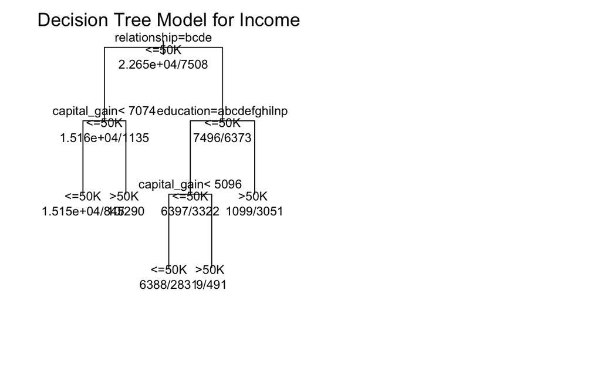

```r
library(rpart)
par(family='Arial Unicode MS')
par(mfrow = c(1,2), xpd = NA)
tree = rpart(income ~ ., data=train, method="class")
plot(tree, uniform=TRUE, main="Decision Tree Model for Income")
text(tree, use.n=TRUE, all=TRUE, cex=.8)
```

```r
summary(tree)
```

```
Call:
rpart(formula = income ~ ., data = train, method = "class")
  n= 30161

          CP nsplit rel error    xerror        xstd
1 0.12999467      0 1.0000000 1.0000000 0.010001793
2 0.06419819      2 0.7400107 0.7400107 0.008966969
3 0.03729355      3 0.6758125 0.6758125 0.008652716
4 0.01000000      4 0.6385189 0.6385189 0.008457392

Variable importance
  relationship marital_status   capital_gain      education  education_num
            24             23             10              9              9
           sex     occupation            age hours_per_week
             8              7              5              3

Node number 1: 30161 observations,    complexity param=0.1299947
  predicted class=<=50K  expected loss=0.2489307  P(node) =1
    class counts: 22653  7508
   probabilities: 0.751 0.249
  left son=2 (16292 obs) right son=3 (13869 obs)
  Primary splits:
      relationship   splits as  RLLLLR, improve=2277.164, (0 missing)
      marital_status splits as  LRRLLLL, improve=2244.398, (0 missing)
      capital_gain   < 5119   to the left,  improve=1540.825, (0 missing)
      education      splits as  LLLLLLLLLRRLRLRL, improve=1193.769, (0 missing)
      education_num  < 12.5   to the left,  improve=1193.769, (0 missing)
  Surrogate splits:
      marital_status splits as  LRRLLLL, agree=0.993, adj=0.984, (0 split)
      sex            splits as  LR, agree=0.691, adj=0.328, (0 split)
      age            < 33.5   to the left,  agree=0.645, adj=0.229, (0 split)
      occupation     splits as  -LLRRRLLLLRRLLR, agree=0.620, adj=0.175, (0 split)
      hours_per_week < 43.5   to the left,  agree=0.604, adj=0.138, (0 split)

Node number 2: 16292 observations,    complexity param=0.03729355
  predicted class=<=50K  expected loss=0.06966609  P(node) =0.5401678
    class counts: 15157  1135
   probabilities: 0.930 0.070
  left son=4 (15992 obs) right son=5 (300 obs)
  Primary splits:
```

[output cut: 45 more lines]

```

Node number 7: 4150 observations
  predicted class=>50K   expected loss=0.2648193  P(node) =0.1375949
    class counts:  1099  3051
   probabilities: 0.265 0.735

Node number 12: 9219 observations
  predicted class=<=50K  expected loss=0.3070832  P(node) =0.3056596
    class counts:  6388  2831
   probabilities: 0.693 0.307

Node number 13: 500 observations
  predicted class=>50K   expected loss=0.018  P(node) =0.0165777
    class counts:     9   491
   probabilities: 0.018 0.982
```

```r
print(tree)
```

```
n= 30161

node), split, n, loss, yval, (yprob)
      * denotes terminal node

 1) root 30161 7508 <=50K (0.75106926 0.24893074)
   2) relationship=Not-in-family,Other-relative,Own-child,Unmarried 16292 1135 <=50K (0.93033391 0.06966609)
     4) capital_gain< 7073.5 15992  845 <=50K (0.94716108 0.05283892) *
     5) capital_gain>=7073.5 300   10 >50K (0.03333333 0.96666667) *
   3) relationship=Husband,Wife 13869 6373 <=50K (0.54048598 0.45951402)
     6) education=10th,11th,12th,1st-4th,5th-6th,7th-8th,9th,Assoc-acdm,Assoc-voc,HS-grad,Preschool,Some-college 9719 3322 <=50K (0.65819529 0.34180471)
      12) capital_gain< 5095.5 9219 2831 <=50K (0.69291680 0.30708320) *
      13) capital_gain>=5095.5 500    9 >50K (0.01800000 0.98200000) *
     7) education=Bachelors,Doctorate,Masters,Prof-school 4150 1099 >50K (0.26481928 0.73518072) *
```

#### (i)

From the summary, we can see that the top 3 important predictors are in turn “relationship”, “marital_status”, “capital_gain”.

#### (ii)

The first split is done on “relationship”. If relationship belongs to one of the following: “Not-in-family”, “Other-relative”, “Own-child”, or “Unmarried”, then classify the object as <=50k. The first node is predicted as <=50k. The observation distribution between “<=50k” and “>50k” is 0.751 and 0.249 respectively.

### (c)

```r
library(caret)
pred = predict(tree, test, type="class")
confusionMatrix(pred, test$income)
```

```
Confusion Matrix and Statistics

          Reference
Prediction <=50K  >50K
     <=50K 10772  1837
     >50K    588  1863

               Accuracy : 0.839
                 95% CI : (0.833, 0.8448)
    No Information Rate : 0.7543
    P-Value [Acc > NIR] : < 2.2e-16

                  Kappa : 0.5098
 Mcnemar's Test P-Value : < 2.2e-16

            Sensitivity : 0.9482
            Specificity : 0.5035
         Pos Pred Value : 0.8543
         Neg Pred Value : 0.7601
             Prevalence : 0.7543
         Detection Rate : 0.7153
   Detection Prevalence : 0.8373
      Balanced Accuracy : 0.7259

       'Positive' Class : <=50K
```

#### (i)

The balanced accuracy of the model = (0.9482 + 0.5035)/2 = 0.726.

#### (ii)

The balanced error rate of the model = 1 - 0.726 = 0.274.

#### (iii)

The sensitivity = 0.948. The specificity = 0.504.

#### (iv)

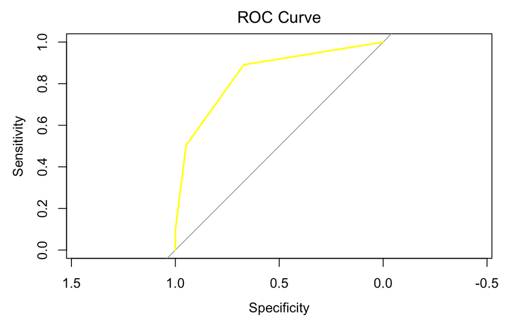

```r
library(pROC)
par(family='Arial Unicode MS')
pred_prob = predict(tree, test, type="prob")
plot(roc(test$income, pred_prob[,2]), col="yellow", main="ROC Curve")
```

```r
auc(test$income, pred_prob[,2])
```

```
Area under the curve: 0.8431
```

The AUC is 0.843.

### (d)

```r
library(rpart)
printcp(tree)
```

```
Classification tree:
rpart(formula = income ~ ., data = train, method = "class")

Variables actually used in tree construction:
[1] capital_gain education    relationship

Root node error: 7508/30161 = 0.24893

n= 30161

        CP nsplit rel error  xerror      xstd
1 0.129995      0   1.00000 1.00000 0.0100018
2 0.064198      2   0.74001 0.74001 0.0089670
3 0.037294      3   0.67581 0.67581 0.0086527
4 0.010000      4   0.63852 0.63852 0.0084574
```

Above lists cp values and cross-validation error (xerror) for each nsplit and can be used to prune the tree. The one with least cross-validated error (xerror) is the optimal value of CP, and we use it to try to prune the tree.

```r
library(caret)
cp = tree$cptable[which.min(tree$cptable[,"xerror"]),"CP"]
ptree <- prune(tree, cp)
ppred = predict(ptree, test, type="class")
confusionMatrix(ppred, test$income)
```

```
Confusion Matrix and Statistics

          Reference
Prediction <=50K  >50K
     <=50K 10772  1837
     >50K    588  1863

               Accuracy : 0.839
                 95% CI : (0.833, 0.8448)
    No Information Rate : 0.7543
    P-Value [Acc > NIR] : < 2.2e-16

                  Kappa : 0.5098
 Mcnemar's Test P-Value : < 2.2e-16

            Sensitivity : 0.9482
            Specificity : 0.5035
         Pos Pred Value : 0.8543
         Neg Pred Value : 0.7601
             Prevalence : 0.7543
         Detection Rate : 0.7153
   Detection Prevalence : 0.8373
      Balanced Accuracy : 0.7259

       'Positive' Class : <=50K
```

```r
base_accuracy <- mean(pred == test$income)
accuracy_postprun <- mean(ppred == test$income)
data.frame(base_accuracy, accuracy_postprun)
```

| base_accuracy | accuracy_postprun |
| --- | --- |
| 0.8389774 | 0.8389774 |

The results show that the tree after pruning get exact same accuracy with no pruning, i.e. no benefit. This maybe because pruning is used to reduce the chances of overfitting the tree to the training data and reduce the overall complexity of the tree, and our original tree model is generalized enough, not that complex.

### (e)

#### (i)

```r
cat("In the training dataset,", "\n")
```

```
In the training dataset,
```

```r
cat("There are", sum(train$income == '<=50K'), "observations in class '<=50K'.", "\n")
```

```
There are 22653 observations in class '<=50K'.
```

```r
cat("There are", sum(train$income == '>50K'), "observations in class '>50K'.")
```

```
There are 7508 observations in class '>50K'.
```

#### (ii)

```r
majority <- train[which(train$income=='<=50K'), ]
minority <- train[which(train$income=='>50K'), ]
smpl <- majority[sample(nrow(majority), size=nrow(minority)), ]
new_train <- rbind(smpl, minority)
new_train
```

|  | age | workclass | fnlwgt | education | education_num | marital_status | occupation | relationship | race | sex | capital_gain | capital_loss | hours_per_week | native_country | income |
| --- | --- | --- | --- | --- | --- | --- | --- | --- | --- | --- | --- | --- | --- | --- | --- |
| 4928 | 21 | Private | 207923 | Some-college | 10 | Married-spouse-absent | Adm-clerical | Own-child | White | Female | 0 | 0 | 15 | United-States | <=50K |
| 19771 | 23 | Self-emp-not-inc | 289116 | HS-grad | 9 | Divorced | Other-service | Unmarried | White | Female | 0 | 0 | 50 | United-States | <=50K |
| 8601 | 31 | Private | 295922 | Some-college | 10 | Never-married | Adm-clerical | Not-in-family | White | Male | 0 | 0 | 40 | United-States | <=50K |
| 19808 | 32 | Private | 207400 | HS-grad | 9 | Never-married | Machine-op-inspct | Unmarried | Black | Female | 0 | 0 | 40 | United-States | <=50K |
| 18886 | 46 | Federal-gov | 106252 | Some-college | 10 | Divorced | Adm-clerical | Not-in-family | White | Female | 0 | 0 | 40 | United-States | <=50K |
| 28336 | 59 | Private | 100453 | 7th-8th | 4 | Separated | Other-service | Own-child | Black | Female | 0 | 0 | 38 | United-States | <=50K |
| 9347 | 27 | Private | 177761 | Some-college | 10 | Married-civ-spouse | Farming-fishing | Husband | Other | Male | 0 | 0 | 50 | United-States | <=50K |
| 27129 | 24 | Private | 239663 | Some-college | 10 | Married-civ-spouse | Adm-clerical | Husband | White | Male | 0 | 0 | 15 | United-States | <=50K |
| 30003 | 20 | Private | 211968 | Some-college | 10 | Never-married | Prof-specialty | Own-child | White | Female | 0 | 0 | 15 | United-States | <=50K |
| 3362 | 21 | Private | 256356 | 11th | 7 | Never-married | Priv-house-serv | Other-relative | White | Female | 0 | 0 | 40 | Mexico | <=50K |

[output cut: 990 more lines]

#### (iii)

```r
library(rpart)
library(caret)
library(pROC)
tree2 = rpart(income ~ ., data=new_train, method="class")
pred2 = predict(tree2, test, type="class")
confusionMatrix(pred2, test$income)
```

```
Confusion Matrix and Statistics

          Reference
Prediction <=50K >50K
     <=50K  8759  612
     >50K   2601 3088

               Accuracy : 0.7867
                 95% CI : (0.78, 0.7932)
    No Information Rate : 0.7543
    P-Value [Acc > NIR] : < 2.2e-16

                  Kappa : 0.5127
 Mcnemar's Test P-Value : < 2.2e-16

            Sensitivity : 0.7710
            Specificity : 0.8346
         Pos Pred Value : 0.9347
         Neg Pred Value : 0.5428
             Prevalence : 0.7543
         Detection Rate : 0.5816
   Detection Prevalence : 0.6222
      Balanced Accuracy : 0.8028

       'Positive' Class : <=50K
```

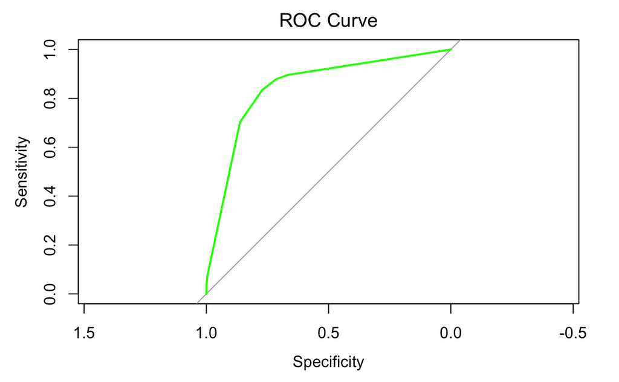

```r
par(family='Arial Unicode MS')
pred_prob2 = predict(tree2, test, type="prob")
plot(roc(test$income, pred_prob2[,2]), col="green", main="ROC Curve")
```

```r
auc(test$income, pred_prob2[,2])
```

```
Area under the curve: 0.8451
```

##### (i)

The balanced accuracy of new tree is 0.802.

##### (ii)

The balanced error rate of new tree is 0.198.

##### (iv)

AUC is 0.845.

### (f)

Results comparison:

The balance accuracy: (e) > (c). The sensitivity: (c) > (e). The specificity: (e) > (c). The AUC: (e) > (c). This shows that after removing the class imbalance impact, we get a better model.

## 2.2 Random Forest

### (a)

```r
library(randomForest)
library(caret)
set.seed(1122)
rf <- randomForest(income ~ ., data=train, importance=TRUE)
pred3 = predict(rf, test, type="class")
confusionMatrix(pred3, test$income)
```

```
Confusion Matrix and Statistics

          Reference
Prediction <=50K  >50K
     <=50K 11328  2711
     >50K     32   989

               Accuracy : 0.8179
                 95% CI : (0.8116, 0.824)
    No Information Rate : 0.7543
    P-Value [Acc > NIR] : < 2.2e-16

                  Kappa : 0.3499
 Mcnemar's Test P-Value : < 2.2e-16

            Sensitivity : 0.9972
            Specificity : 0.2673
         Pos Pred Value : 0.8069
         Neg Pred Value : 0.9687
             Prevalence : 0.7543
         Detection Rate : 0.7522
   Detection Prevalence : 0.9322
      Balanced Accuracy : 0.6322

       'Positive' Class : <=50K
```

#### (i)

The balanced accuracy of the random forest is 0.632.

#### (ii)

The accuracy of the random forest is 0.818.

#### (iii)

Sensitivity is 0.997. Specificity is 0.267.

#### (iv)

There are (32+989)= 1021 observations labeled “>50K”, and (11328+2711)= 14039 observations labeled “<=50K”.

#### (v)

Yes, make sense. Sensitivity = 11328/(11328+32) = 0.997. Specificity = 989/(989+2711) = 0.267.

#### (vi)

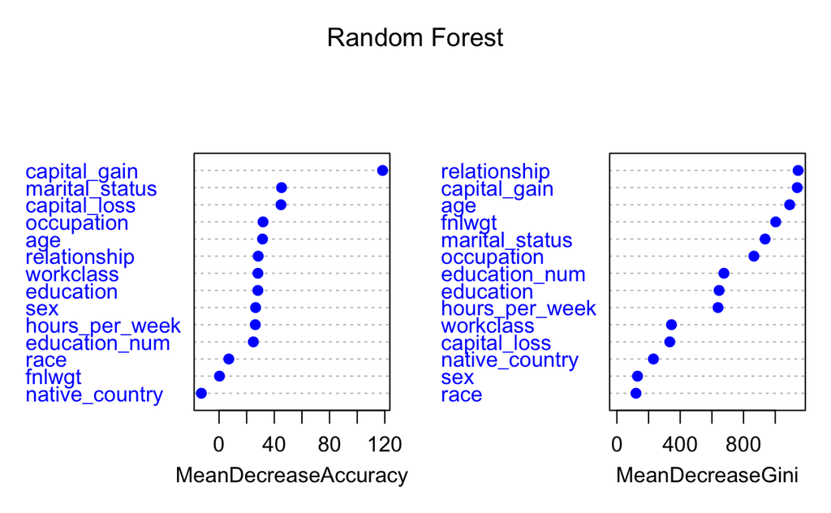

```r
par(family='Arial Unicode MS')
varImpPlot(rf, pch=19, col='blue', main='Random Forest')
```

For MeanDecreaseAccuracy, “capital_gain” is the most important variable, and “native_country” is the least important one.

For MeanDecreaseGini, “relationship” is the most important variable, and “race” is the least important one.

#### (vii)

```r
print(rf)
```

```
Call:
 randomForest(formula = income ~ ., data = train, importance = TRUE)
               Type of random forest: classification
                     Number of trees: 500
No. of variables tried at each split: 3

        OOB estimate of  error rate: 18.19%
Confusion matrix:
      <=50K >50K class.error
<=50K 22592   61   0.0026928
>50K   5424 2084   0.7224294
```

The number of variables tried at each split is 3.

### (b)

```
mtry = 3  OOB error = 18.19%
Searching left ...
mtry = 2    OOB error = 17.78%
0.02242071 0.01
Searching right ...
mtry = 4    OOB error = 18.15%
-0.02088383 0.01
```

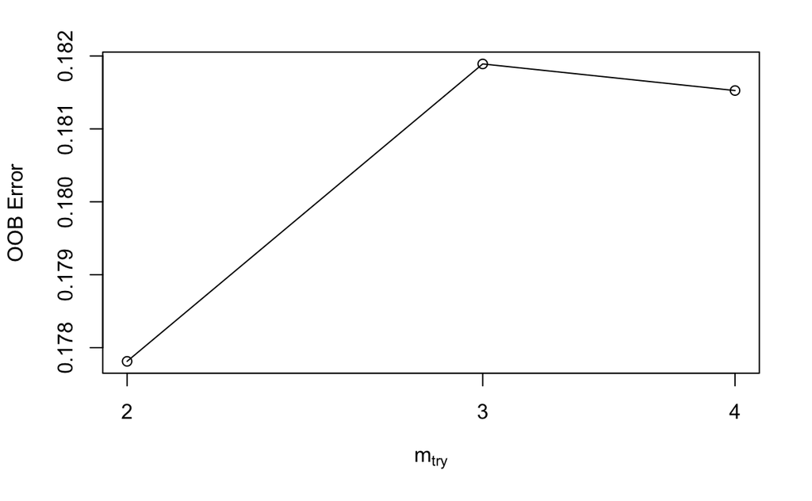

```r
set.seed(1122)
par(family='Arial Unicode MS')
X <- train[ , -15]
Y <- train[ , 15]
mtry <- tuneRF(X, Y, ntreeTry=500, stepFactor=1.5,improve=0.01, trace=TRUE, plot=TRUE)
```

```r
print(mtry)
```

```
      mtry  OOBError
2.OOB    2 0.1778124
3.OOB    3 0.1818905
4.OOB    4 0.1815258
```

#### (i)

For classification, the default value of mtry is the square root of the number of predictors in X, sqrt(14) = 3.

#### (ii)

The optimal value of mtry suggested is 2, which has the lowest OOB error.

#### (iii)

```r
set.seed(1122)
rf2 <- randomForest(income ~ ., data=train, importance=TRUE, mtry=2)
pred4 = predict(rf2, test, type="class")
confusionMatrix(pred4, test$income)
```

```
Confusion Matrix and Statistics

          Reference
Prediction <=50K  >50K
     <=50K 11326  2667
     >50K     34  1033

               Accuracy : 0.8207
                 95% CI : (0.8144, 0.8267)
    No Information Rate : 0.7543
    P-Value [Acc > NIR] : < 2.2e-16

                  Kappa : 0.3634
 Mcnemar's Test P-Value : < 2.2e-16

            Sensitivity : 0.9970
            Specificity : 0.2792
         Pos Pred Value : 0.8094
         Neg Pred Value : 0.9681
             Prevalence : 0.7543
         Detection Rate : 0.7521
   Detection Prevalence : 0.9292
      Balanced Accuracy : 0.6381

       'Positive' Class : <=50K
```

##### (1)

The balanced accuracy of the model is 0.638.

##### (2)

The accuracy of the model is 0.821.

##### (3)

Sensitivity is 0.997. Specificity is 0.279.

##### (5)

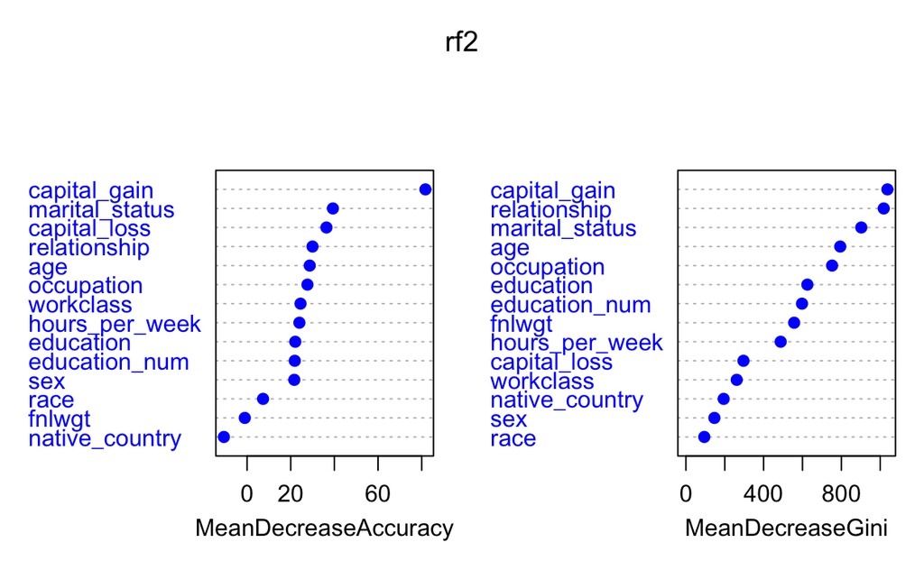

```r
par(family='Arial Unicode MS')
varImpPlot(rf2, pch=19, col='blue')
```

For MeanDecreaseAccuracy, “capital_gain” is the most important variable, and “native_country” is the least important one.

For MeanDecreaseGini, “capital_gain” is the most important variable, and “race” is the least important one.

#### (vi)

Results comparison:

The balance accuracy: (b) > (a). The sensitivity: (b) ~= (a). The specificity: (b) > (a). variable importance in (b) has more purity on both measurements, while in (a) has different most important ones on both measurements. These comparisons show that after tuning random forest model, we get a better model.

## 2.3 Association Rules

```r
library(arules)
tr <- read.transactions("groceries.csv", format = "basket", sep=",")
```

### (i)

```r
rules <- apriori(tr)
```

```
Apriori

Parameter specification:
 confidence minval smax arem  aval originalSupport maxtime support minlen maxlen
        0.8    0.1    1 none FALSE            TRUE       5     0.1      1     10
 target   ext
  rules FALSE

Algorithmic control:
 filter tree heap memopt load sort verbose
    0.1 TRUE TRUE  FALSE TRUE    2    TRUE

Absolute minimum support count: 983

set item appearances ...[0 item(s)] done [0.00s].
set transactions ...[169 item(s), 9835 transaction(s)] done [0.01s].
sorting and recoding items ... [8 item(s)] done [0.00s].
creating transaction tree ... done [0.00s].
checking subsets of size 1 2 done [0.00s].
writing ... [0 rule(s)] done [0.00s].
creating S4 object  ... done [0.00s].
```

```r
summary(rules)
```

```
set of 0 rules
```

Using default minsup = 0.1, we get 0 rules.

### (ii)

```r
rules <- apriori(tr, parameter = list(supp=0.001, target='rules'))
```

```
Apriori

Parameter specification:
 confidence minval smax arem  aval originalSupport maxtime support minlen maxlen
        0.8    0.1    1 none FALSE            TRUE       5   0.001      1     10
 target   ext
  rules FALSE

Algorithmic control:
 filter tree heap memopt load sort verbose
    0.1 TRUE TRUE  FALSE TRUE    2    TRUE

Absolute minimum support count: 9

set item appearances ...[0 item(s)] done [0.00s].
set transactions ...[169 item(s), 9835 transaction(s)] done [0.01s].
sorting and recoding items ... [157 item(s)] done [0.00s].
creating transaction tree ... done [0.01s].
checking subsets of size 1 2 3 4 5 6 done [0.03s].
writing ... [410 rule(s)] done [0.00s].
creating S4 object  ... done [0.01s].
```

```r
summary(rules)
```

```
set of 410 rules

rule length distribution (lhs + rhs):sizes
  3   4   5   6
 29 229 140  12

   Min. 1st Qu.  Median    Mean 3rd Qu.    Max.
  3.000   4.000   4.000   4.329   5.000   6.000

summary of quality measures:
    support           confidence          lift            count
 Min.   :0.001017   Min.   :0.8000   Min.   : 3.131   Min.   :10.00
 1st Qu.:0.001017   1st Qu.:0.8333   1st Qu.: 3.312   1st Qu.:10.00
 Median :0.001220   Median :0.8462   Median : 3.588   Median :12.00
 Mean   :0.001247   Mean   :0.8663   Mean   : 3.951   Mean   :12.27
 3rd Qu.:0.001322   3rd Qu.:0.9091   3rd Qu.: 4.341   3rd Qu.:13.00
 Max.   :0.003152   Max.   :1.0000   Max.   :11.235   Max.   :31.00

mining info:
 data ntransactions support confidence
   tr          9835   0.001        0.8
```

At support value = 0.001, we get at least 400 rules.

### (iii)

```r
itemfreq <- data.frame(itemFrequency(tr, type='absolute'))
mostitem <- rownames(itemfreq)[apply(itemfreq, 2, which.max)]
mostitem
```

```
[1] "whole milk"
```

```r
itemfreq[mostitem, ]
```

```
[1] 2513
```

The most frequently bought item is “whole milk”. Its frequency is 2513.

### (iv)

```r
leastitem <- rownames(itemfreq)[apply(itemfreq, 2, which.min)]
leastitem
```

```
[1] "baby food"
```

```r
itemfreq[leastitem, ]
```

```
[1] 1
```

The least frequently bought item is “baby food”. Its frequency is 1.

### (v)

Here are top 5 rules sorted by support.

```r
top_supp <- sort(rules, decreasing = TRUE, na.last = NA, by = "support")
inspect(head(top_supp, 5))
```

```
    lhs                   rhs                    support confidence     lift count
[1] {citrus fruit,
     root vegetables,
     tropical fruit,
     whole milk}       => {other vegetables} 0.003152008  0.8857143 4.577509    31
[2] {curd,
     domestic eggs,
     other vegetables} => {whole milk}       0.002846975  0.8235294 3.223005    28
[3] {curd,
     hamburger meat}   => {whole milk}       0.002541942  0.8064516 3.156169    25
[4] {herbs,
     rolls/buns}       => {whole milk}       0.002440264  0.8000000 3.130919    24
[5] {herbs,
     tropical fruit}   => {whole milk}       0.002338587  0.8214286 3.214783    23
```

### (vi)

Here are top 5 rules sorted by confidence.

```r
top_conf <- sort(rules, decreasing = TRUE, na.last = NA, by = "confidence")
inspect(head(top_conf, 5))
```

```
    lhs                     rhs              support confidence     lift count
[1] {rice,
     sugar}              => {whole milk} 0.001220132          1 3.913649    12
[2] {canned fish,
     hygiene articles}   => {whole milk} 0.001118454          1 3.913649    11
[3] {butter,
     rice,
     root vegetables}    => {whole milk} 0.001016777          1 3.913649    10
[4] {flour,
     root vegetables,
     whipped/sour cream} => {whole milk} 0.001728521          1 3.913649    17
[5] {butter,
     domestic eggs,
     soft cheese}        => {whole milk} 0.001016777          1 3.913649    10
```

### (vii)

Here are bottom 5 rules sorted by support.

```r
bot_supp <- sort(rules, decreasing = FALSE, na.last = NA, by = "support")
inspect(head(bot_supp, 5))
```

```
    lhs                                       rhs          support     confidence
[1] {cereals,curd}                         => {whole milk} 0.001016777 0.9090909
[2] {butter,jam}                           => {whole milk} 0.001016777 0.8333333
[3] {pastry,sweet spreads}                 => {whole milk} 0.001016777 0.9090909
[4] {butter,rice,root vegetables}          => {whole milk} 0.001016777 1.0000000
[5] {other vegetables,rice,tropical fruit} => {whole milk} 0.001016777 0.8333333
    lift     count
[1] 3.557863 10
[2] 3.261374 10
[3] 3.557863 10
[4] 3.913649 10
[5] 3.261374 10
```

### (viii)

Here are bottom 5 rules sorted by confidence.

```r
bot_conf <- sort(rules, decreasing = FALSE, na.last = NA, by = "confidence")
inspect(head(bot_conf, 5))
```

```
    lhs                        rhs                    support confidence     lift count
[1] {curd,
     turkey}                => {other vegetables} 0.001220132        0.8 4.134524    12
[2] {fruit/vegetable juice,
     herbs}                 => {other vegetables} 0.001220132        0.8 4.134524    12
[3] {herbs,
     rolls/buns}            => {whole milk}       0.002440264        0.8 3.130919    24
[4] {onions,
     waffles}               => {other vegetables} 0.001220132        0.8 4.134524    12
[5] {root vegetables,
     tropical fruit,
     turkey}                => {other vegetables} 0.001220132        0.8 4.134524    12
```